# Introduction to the EAinference package

Seunghyun Min

2017-12-01

`EAinference` package is designed to facilitate simulation based inference of lasso type estimators. The package includes

- Fitting the lasso, group lasso, scaleld lasso and scaled group lasso models
- Gaussian and wild multiplier bootstrap for lasso, group lasso, scaled lasso, scaled group lasso and their de-biased estimators
- Importance sampler for approximating p-values in these methods
- Markov chain Monte Carlo lasso sampler with applications in post-selection inference.

## Loss functions

Let the unknown true model be
$$y = X\beta_0 + \epsilon,$$
where $\beta_0$ is a unknown true coefficient vector and $\epsilon_i \sim_{iid} N(0,\sigma^2)$.

We use following loss functions.
$$\ell_{grlasso}(\beta ; \lambda) = \frac{1}{2}||y-X\beta||^2_2 + n\lambda\sum_j w_j||\beta_{(j)}||_2,$$
$$\ell_{sgrlasso}(\beta, \sigma ; \lambda) = \frac{1}{2\sigma}||y-X\beta||^2_2 + \frac{\sigma}{2} + n\lambda\sum_j w_j||\beta_{(j)}||_2,$$
where $grlasso$ and $sgrlasso$ represent group lasso and scaled group lasso, respectively, and $w_j$ is the weight factor for the $j$-th group. Loss functions for lasso and scaled lasso can be treated as special cases of group lasso and group scaled lasso when every group is a singleton, respectively.

## Fit lasso, group lasso, scaled lasso and scaled group lasso models

`lassoFit` computes lasso, group lasso, scaled lasso and scaled group lasso solutions. Users can either provide the value of $\lambda$ or choose to use cross-validation by setting `lbd = "cv.min"` or `lbd = "cv.1se"`. By letting `lbd = "cv.min"`, users can have $\lambda$ which gives minimum mean-squared error, while `lbd = "cv.1se"` is the largest $\lambda$ within 1 standard deviaion error bound of `"cv.min"`.

```r
library(EAinference)
set.seed(1234)
n <- 30; p <- 50
Niter <-  10
group <- rep(1:(p/5), each = 5)
weights <- rep(1, p/5)
beta0 <- c(rep(1,5), rep(0, p-5))
X <- matrix(rnorm(n*p), n)
Y <- X %*% beta0 + rnorm(n)
# set lambda = .5
lassoFit(X = X, Y = Y, lbd = .5, group = group, weights = weights, type="grlasso")
```

```
## $B0
##  [1]  0.5161666451  1.0188194987  0.6824793388  0.3931465866  0.6874994287
##  [6] -0.0016276550  0.0217320293  0.0301747719 -0.0099519996 -0.0164145624
## [11] -0.0014113541 -0.0045361968  0.0020838981  0.0005231764 -0.0052660052
## [16]  0.0000000000  0.0000000000  0.0000000000  0.0000000000  0.0000000000
## [21]  0.0000000000  0.0000000000  0.0000000000  0.0000000000  0.0000000000
## [26]  0.0000000000  0.0000000000  0.0000000000  0.0000000000  0.0000000000
## [31]  0.0000000000  0.0000000000  0.0000000000  0.0000000000  0.0000000000
## [36]  0.0000000000  0.0000000000  0.0000000000  0.0000000000  0.0000000000
## [41] -0.0017693962 -0.0011635879  0.0061087716  0.0010330827 -0.0028810035
## [46]  0.0000000000  0.0000000000  0.0000000000  0.0000000000  0.0000000000
##
## $S0
##  [1]  0.33335824  0.65800255  0.44077947  0.25391509  0.44402031
##  [6] -0.03886814  0.51891926  0.72052006 -0.23763656 -0.39194621
```

[output cut: 19 more lines]

```r
# use cross-validation
lassoFit(X = X, Y = Y, lbd = "cv.1se", group = group, weights = weights, type="grlasso")
```

```
## $B0
##  [1] 0.2585567 0.5662969 0.3423216 0.1790861 0.3370465 0.0000000 0.0000000
##  [8] 0.0000000 0.0000000 0.0000000 0.0000000 0.0000000 0.0000000 0.0000000
## [15] 0.0000000 0.0000000 0.0000000 0.0000000 0.0000000 0.0000000 0.0000000
## [22] 0.0000000 0.0000000 0.0000000 0.0000000 0.0000000 0.0000000 0.0000000
## [29] 0.0000000 0.0000000 0.0000000 0.0000000 0.0000000 0.0000000 0.0000000
## [36] 0.0000000 0.0000000 0.0000000 0.0000000 0.0000000 0.0000000 0.0000000
## [43] 0.0000000 0.0000000 0.0000000 0.0000000 0.0000000 0.0000000 0.0000000
## [50] 0.0000000
##
## $S0
##  [1]  0.320602499  0.702188704  0.424466187  0.222062331  0.417926026
##  [6] -0.082467976  0.277804727  0.096219628 -0.208633518 -0.139425279
## [11] -0.045785563 -0.085990733  0.311352884  0.011898323 -0.431104404
## [16]  0.434035959  0.080054096  0.099761888  0.383888283 -0.046916332
```

[output cut: 17 more lines]

## Parametric bootstrap sampler

`PBsampler` supports two bootstrap methods; Gaussian bootstrap and wild multiplier bootstrap. Due to the fact that the sampling distirbution of $(\hat{\beta}, S)$, coefficient estimator and its subgradient, is characterized by $(\beta_0, \sigma^2, \lambda)$, users are required to provide `PE`(either the estimate of $\beta_0$ or the estimate of $E(y) = X\beta_0$), `sig2`(or estimate of $\sigma^2$) and `lbd`($\lambda$ from above loss functions).

By specifying two sets of arguments, `(PE_1, sig2_1, lbd_1)` and `(PE_2, sig2_2, lbd_2)`, users can sample from the mixture distribution. In this way, samples will be drawn from `(PE_1, sig2_1, lbd_1)` with 1/2 probability and from `(PE_2, sig2_2, lbd_2)` with another 1/2 probability.

```r
set.seed(1234)
n <- 5; p <- 10
Niter <-  3
group <- rep(1:(p/5), each = 5)
weights <- rep(1, p/5)
beta0 <- c(rep(1,5), rep(0, p-5))
X <- matrix(rnorm(n*p), n)
Y <- X %*% beta0 + rnorm(n)
#
# Using non-mixture distribution
#
PBsampler(X = X, PE_1 = rep(0, p), sig2_1 = 1, lbd_1 = .5,
weights = weights, group = group, type = "grlasso", niter = Niter, parallel = FALSE)
```

```
## $beta
##            [,1]        [,2]         [,3]        [,4]       [,5]
## [1,] -0.3525372 -0.04505232 -0.163496084 -0.20736594 0.04096835
## [2,]  0.0000000  0.00000000  0.000000000  0.00000000 0.00000000
## [3,] -0.1019592 -0.01026948  0.007230875 -0.04528641 0.02613062
##             [,6]        [,7]         [,8]        [,9]       [,10]
## [1,]  0.07989826  0.01441626 -0.078991476 -0.01728012 -0.02587893
## [2,]  0.19450800  0.10014585 -0.449697335 -0.06017330 -0.11895590
## [3,] -0.48573785 -0.02475042  0.003966679  0.16608124 -0.22664921
##
## $subgrad
##            [,1]        [,2]        [,3]       [,4]        [,5]       [,6]
## [1,] -0.7928269 -0.10133122 -0.36770991 -0.4663535  0.09212409  0.6801195
## [2,]  0.5445986  0.06272791 -0.41645041  0.2135834 -0.29673172  0.3757996
## [3,] -0.8845247 -0.08909051  0.06272808 -0.3928755  0.22669099 -0.8647542
##             [,7]         [,8]       [,9]      [,10]
## [1,]  0.12271068 -0.672414957 -0.1471035 -0.2202979
## [2,]  0.19352241 -0.868867603 -0.1162979 -0.2298557
## [3,] -0.04405627  0.007096803  0.2956620 -0.4035373
##
## $X
##            [,1]       [,2]        [,3]       [,4]       [,5]       [,6]
## [1,] -1.2070657  0.5060559 -0.47719270 -0.1102855  0.1340882 -1.4482049
## [2,]  0.2774292 -0.5747400 -0.99838644 -0.5110095 -0.4906859  0.5747557
## [3,]  1.0844412 -0.5466319 -0.77625389 -0.9111954 -0.4405479 -1.0236557
## [4,] -2.3456977 -0.5644520  0.06445882 -0.8371717  0.4595894 -0.0151383
## [5,]  0.4291247 -0.8900378  0.95949406  2.4158352 -0.6937202 -0.9359486
##            [,7]       [,8]       [,9]      [,10]
## [1,]  1.1022975 -1.1676193  1.4494963 -0.9685143
## [2,] -0.4755931 -2.1800396 -1.0686427 -1.1073182
## [3,] -0.7094400 -1.3409932 -0.8553646 -1.2519859
## [4,] -0.5012581 -0.2942939 -0.2806230 -0.5238281
## [5,] -1.6290935 -0.4658975 -0.9943401 -0.4968500
##
## $PE
##  [1] 0 0 0 0 0 0 0 0 0 0
##
## $sig2
## [1] 1
##
```

[output cut: 15 more lines]

```
## $Btype
## [1] "gaussian"
##
## $Y
## NULL
##
## $mixture
## [1] FALSE
##
## $call
## PBsampler(X = X, PE_1 = rep(0, p), sig2_1 = 1, lbd_1 = 0.5, weights = weights,
##     group = group, niter = Niter, type = "grlasso", parallel = FALSE)
##
## attr(,"class")
## [1] "PB"
```

```r
#
# Using mixture distribution
#
PBsampler(X = X, PE_1 = rep(0, p), sig2_1 = 1, lbd_1 = .5,
 PE_2 = rep(1, p), sig2_2 = 2, lbd_2 = .3, weights = weights,
 group = group, type = "grlasso", niter = Niter, parallel = FALSE)
```

```
## $beta
##            [,1]       [,2]        [,3]       [,4]        [,5]        [,6]
## [1,]  0.0000000  0.0000000  0.00000000  0.0000000  0.00000000 -0.27036272
## [2,] -0.3321355 -0.3335305 -0.04145217 -0.4657345  0.06209445 -0.08106727
## [3,]  1.2724686  0.7145404  0.26382548  0.7718595 -0.07766709  0.28111670
##            [,7]        [,8]       [,9]      [,10]
## [1,]  0.1244449 -0.15833798  0.2244849 -0.1545494
## [2,] -0.3907588 -0.08506543 -0.3701445 -0.2274632
## [3,]  1.2572062  1.56849000  1.1991659  1.4822653
##
## $subgrad
##            [,1]       [,2]        [,3]       [,4]        [,5]       [,6]
## [1,] -0.6154729  0.1204288 -0.02636072  0.1638148  0.05509138 -0.6236691
## [2,] -0.4984384 -0.5005026 -0.06221061 -0.6989186  0.09317068 -0.1360223
## [3,]  0.7602823  0.4269187  0.15762952  0.4611765 -0.04640962  0.1009130
##            [,7]       [,8]       [,9]      [,10]
## [1,]  0.2870925 -0.3652346  0.5177945 -0.3565099
## [2,] -0.6555875 -0.1427033 -0.6210494 -0.3816455
## [3,]  0.4514828  0.5632085  0.4305853  0.5323487
##
## $X
##            [,1]       [,2]        [,3]       [,4]       [,5]       [,6]
## [1,] -1.2070657  0.5060559 -0.47719270 -0.1102855  0.1340882 -1.4482049
## [2,]  0.2774292 -0.5747400 -0.99838644 -0.5110095 -0.4906859  0.5747557
## [3,]  1.0844412 -0.5466319 -0.77625389 -0.9111954 -0.4405479 -1.0236557
## [4,] -2.3456977 -0.5644520  0.06445882 -0.8371717  0.4595894 -0.0151383
## [5,]  0.4291247 -0.8900378  0.95949406  2.4158352 -0.6937202 -0.9359486
##            [,7]       [,8]       [,9]      [,10]
## [1,]  1.1022975 -1.1676193  1.4494963 -0.9685143
## [2,] -0.4755931 -2.1800396 -1.0686427 -1.1073182
## [3,] -0.7094400 -1.3409932 -0.8553646 -1.2519859
## [4,] -0.5012581 -0.2942939 -0.2806230 -0.5238281
## [5,] -1.6290935 -0.4658975 -0.9943401 -0.4968500
##
## $PE
##      [,1] [,2] [,3] [,4] [,5] [,6] [,7] [,8] [,9] [,10]
## PE_1    0    0    0    0    0    0    0    0    0     0
## PE_2    1    1    1    1    1    1    1    1    1     1
##
## $sig2
```

[output cut: 18 more lines]

```
## [1] "gaussian"
##
## $Y
## NULL
##
## $mixture
## [1] TRUE
##
## $call
## PBsampler(X = X, PE_1 = rep(0, p), sig2_1 = 1, lbd_1 = 0.5, PE_2 = rep(1,
##     p), sig2_2 = 2, lbd_2 = 0.3, weights = weights, group = group,
##     niter = Niter, type = "grlasso", parallel = FALSE)
##
## attr(,"class")
## [1] "PB"
```

## Importance sampler for high dimensional data

Importance sampler enables users to access the inference of an extreme region. This is done by using a proposal distiribution that is denser around the extreme region.

Say that we are interested in computing the expectation of a function of a random variable, $h(X)$. Let $f(x)$ be the true or target distribution and $g(x)$ be the proposal distribution. We can approximate the expectation by a weighted average of samples drawn from the proposal distribution as follows,

$$\begin{eqnarray}
E_f\Big[h(X)\Big] &=& E_g \Big[h(X)\frac{f(X)}{g(X)} \Big]\\
&\approx& \frac{1}{N}\sum_{i=1}^N h(x_i)\frac{f(x_i)}{g(x_i)}.
\end{eqnarray}$$
By using `hdIS` method, one can easily compute the importance weight which is the ratio of target density over proposal density; $f(x_i)/g(x_i)$ from above equation.

Users can simply draw samples from the proposal distribution using `PBsampler` and plug in the result into `hdIS` with target distribution parameters in order to compute the importance weights.

```r
# Target distribution parameter
PETarget <- rep(0, p)
sig2Target <- .5
lbdTarget <- .37
# Proposal distribution parameter
PEProp1 <- rep(1, p)
sig2Prop1 <- .5
lbdProp1 <- 1

# Draw samples from proposal distribution
PB <- PBsampler(X = X, PE_1 = PEProp1, sig2_1 = sig2Prop1,
 lbd_1 = lbdProp1, weights = weights, group = group, niter = Niter,
 type="grlasso", PEtype = "coeff")

# Compute importance weights
hdIS(PB, PETarget = PETarget, sig2Target = sig2Target, lbdTarget = lbdTarget,
log = TRUE)
```

```
## [1]  -96.45903 -126.87442  -69.81881
```

## Metropolis-Hastings Lasso Sampler

In this section, we introduce `MHLS` method, a Markov Chain Monte Carlo(MCMC) sampler for lasso estimator. Although bootstrapping is one of the most convenient sampling methods, it has a clear limitation which is that sampling from the conditional distribution is impossible. In contrast, MCMC sampler can easily draw samples from the conditional distribution. Here, we introduce `MHLS` function which draws lasso samples under the fixed active set, A.

```r
weights <- rep(1,p)
lbd <- .37
LassoResult <- lassoFit(X = X,Y = Y,lbd = lbd, type = "lasso", weights = weights)
B0 <- LassoResult$B0
S0 <- LassoResult$S0
Result <- MHLS(X = X, PE = B0, sig2 = 1, lbd = 1,
    weights = weights, B0 = B0, S0 = S0, niter = 100, burnin = 0,
    PEtype = "coeff")
Result
```

```
## ===========================
## Number of iteration:  100
##
## Burn-in period:  0
##
## Plug-in PE:
##  [1] 0.7995661 0.0000000 0.0000000 0.9605262 0.0000000 0.0000000 0.0000000
##  [8] 0.8458788 0.0000000 0.6141082
## PEtype:
## [1] "coeff"
##
## Last 10 steps of beta's:
##            [,1] [,2] [,3]      [,4] [,5] [,6] [,7]      [,8] [,9]
##  [1,] 0.6461477    0    0 1.0846858    0    0    0 0.4806811    0
##  [2,] 0.3534608    0    0 1.0846858    0    0    0 0.3844643    0
##  [3,] 0.3534608    0    0 0.4931794    0    0    0 0.9696950    0
##  [4,] 0.3449473    0    0 0.4931794    0    0    0 0.9696950    0
##  [5,] 0.3449473    0    0 0.4931794    0    0    0 0.9696950    0
##  [6,] 0.3449473    0    0 0.4931794    0    0    0 0.9696950    0
##  [7,] 0.3449473    0    0 0.4931794    0    0    0 0.9696950    0
##  [8,] 0.3449473    0    0 0.4680849    0    0    0 0.9353218    0
##  [9,] 0.3449473    0    0 0.4680849    0    0    0 0.3042383    0
## [10,] 0.3449473    0    0 0.4680849    0    0    0 0.3042383    0
##           [,10]
##  [1,] 0.2336445
##  [2,] 0.2336445
##  [3,] 0.2336445
##  [4,] 0.2336445
##  [5,] 0.2336445
##  [6,] 0.2336445
##  [7,] 0.2336445
##  [8,] 0.2336445
##  [9,] 0.7305437
## [10,] 0.7305437
##
## last 10 steps of subgradients:
##           [,1]       [,2]      [,3]      [,4]        [,5]      [,6]
##  [1,] 1.000003 0.20751105 0.5348776 0.9999994 -0.13120222 0.8152837
##  [2,] 1.000003 0.19902287 0.5373069 0.9999994 -0.13266943 0.8230570
##  [3,] 1.000003 0.14644498 0.5523550 0.9999994 -0.14175768 0.8712067
```

[output cut: 10 more lines]

```
##  [3,] -0.11547926 1.000024 -0.21649131     1
##  [4,] -0.11547926 1.000024 -0.21649131     1
##  [5,] -0.18965806 1.000024 -0.29867431     1
##  [6,] -0.28917162 1.000024 -0.40892581     1
##  [7,] -0.18342296 1.000024 -0.29176642     1
##  [8,] -0.18342296 1.000024 -0.29176642     1
##  [9,]  0.38420566 1.000024  0.33711177     1
## [10,]  0.14450535 1.000024  0.07154677     1
##
## Acceptance rate:
## -----------------------------
##           beta    subgrad
## # Accepted    :   122     62
## # Moved       :   396     99
## Acceptance rate   :   0.308   0.626
```

We provide summary and plot functions for `MHLS` results.

```r
summary(Result)
```

```
## $beta
##            mean    median       s.d       2.5%     97.5%
##  [1,] 0.3987769 0.3449473 0.2007944 0.11304538 0.8853218
##  [2,] 0.0000000 0.0000000 0.0000000 0.00000000 0.0000000
##  [3,] 0.0000000 0.0000000 0.0000000 0.00000000 0.0000000
##  [4,] 0.5038473 0.4931794 0.3748674 0.04885877 1.0846858
##  [5,] 0.0000000 0.0000000 0.0000000 0.00000000 0.0000000
##  [6,] 0.0000000 0.0000000 0.0000000 0.00000000 0.0000000
##  [7,] 0.0000000 0.0000000 0.0000000 0.00000000 0.0000000
##  [8,] 0.5765659 0.6186559 0.3053770 0.04618138 1.1025196
##  [9,] 0.0000000 0.0000000 0.0000000 0.00000000 0.0000000
## [10,] 0.3805857 0.3966923 0.2790838 0.03606252 0.8890657
##
## $subgradient
##              mean     median        s.d        2.5%       97.5%
##  [1,]  1.00000314  1.0000031 0.00000000  1.00000314  1.00000314
##  [2,]  0.29514219  0.2500872 0.18012879  0.06101587  0.71133476
##  [3,]  0.50979702  0.5226920 0.05155390  0.39068031  0.57680532
##  [4,]  0.99999936  0.9999994 0.00000000  0.99999936  0.99999936
##  [5,] -0.11605491 -0.1238428 0.03113581 -0.15652436 -0.04411475
##  [6,]  0.73503303  0.7762934 0.16495796  0.35389307  0.94944074
##  [7,]  0.11470115  0.0449569 0.27883589 -0.24772187  0.75895921
##  [8,]  1.00002402  1.0000240 0.00000000  1.00002402  1.00002402
##  [9,]  0.03852656 -0.0387434 0.30892348 -0.36300346  0.75230284
## [10,]  1.00000000  1.0000000 0.00000000  1.00000000  1.00000000
##
## attr(,"class")
## [1] "summary.MHLS"
```

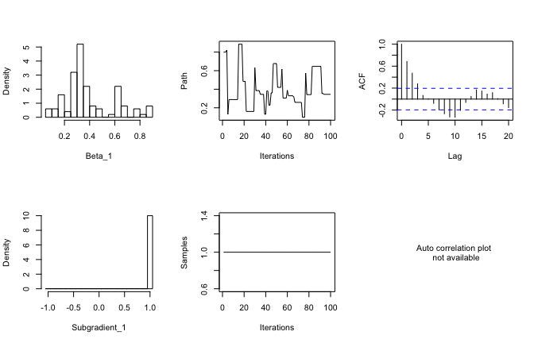

```
## Hit <Return> to see the next plot:
```

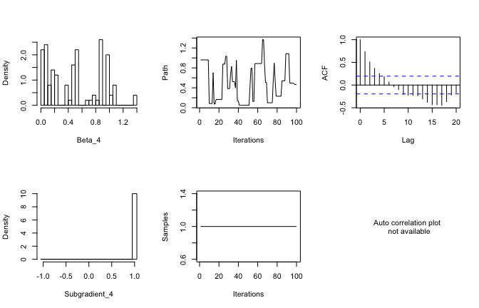

```
## Hit <Return> to see the next plot:
```

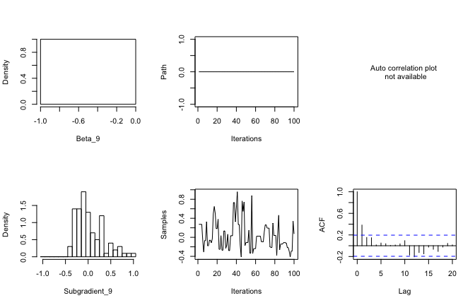

```
## Hit <Return> to see the next plot:
```

```r
plot(Result, index=c(1,4,9))
```

## Post-selection Inference

`postInference.MHLS` is a method for post-selection inference. The inference is provided by `MHLS` results from multiple chains. In order to achieve the robust result, different `PE` values are used for each chain. After drawing samples of $(\hat{\beta}, S)$ with MH sampler, we then refit the estimator to remove the bias of the lasso estimator. The final output is the $(1-a)$ quantile of each active coefficient.

```r
postInference.MHLS(X = X, Y = Y, lbd = lbd, sig2.hat = 1, alpha = .05,
 method = "coeff", nChain = 5, niterPerChain = 20,
 parallel = !(.Platform$OS.type == "windows"))
```

```
##                 beta1       beta4      beta8     beta10
## LowerBound -0.2274856 -0.06173088 -0.8538049 -0.1946631
## UpperBound  2.5068937  2.09967452  0.9623414  2.4811133
```